# Marker thinning for joint-linkage mapping — provenance & proof

What produced the TeoNAM JLM marker framework, and why it has 9063 markers where Chen 2019 had 4578

Author

Fausto Rodríguez-Zapata

Published

July 10, 2026

**What this is.** A self-contained, *hard-proven* record of the marker-thinning step that builds the JLM marker framework (`data/teonam/tassel/geno.hmp.txt`, 9063 markers). Every claim below is reproduced live from the primary data — no approximations, no “close enough.” The three things this notebook nails down:

1. **What the thinning actually was** — `nilHMM::select_independent` (FastIndep, deterministic greedy) run on a **cM-distance** matrix at 0.1 cM, *not* on an r² LD matrix. Reproduced **bit-for-bit** (Jaccard = 1.000) against the file on disk.
2. **What that means** — feeding FastIndep cM distances reduces it to a 0.1 cM minimum-spacing ruler; LD plays no role. We prove the distinction by running *both* variants on the same chromosome and showing they disagree.
3. **Why 9063 and not Chen’s 4578** — a deterministic consequence of the native map’s finer per-marker resolution (bin saturation) at essentially Chen’s map length, decomposed to the marker.

```r
library(here)
library(data.table)
library(ggplot2)
suppressMessages(devtools::load_all("/Users/fvrodriguez/repos/nilhmm", quiet = TRUE))
theme_set(theme_bw(base_size = 12))
THR <- 0.1 # cM thinning threshold
```

## The two published methods (Chen et al. 2019)

Chen 2019 (*Genetics* 213:1065–1078) used **two separate marker sets** for its two mapping methods. Quoting the Methods verbatim:

> *“Because stepwise regression is computationally intensive, we thinned SNPs within 0.1 cM. We finally obtained **4578 markers** for subsequent joint linkage analysis.”* — (JLM marker set)

> *“…a total of **118,838 SNPs** were kept and used for GWAS. GWAS was performed using a linear mixed model accounting for population structure (Q) and kinship matrix (K)…”* — (GWAS marker set, a different pipeline)

This notebook concerns the **JLM** set only (the 4578-marker analogue). The paper’s composite genetic map is **1540 cM**; ours (native TeoNAM est.map cM) is ~1561 cM — so map *length* is essentially Chen’s, and the count difference is instead driven by how finely the native map resolves markers into 0.1-cM bins, as we show below.

## The thinning as implemented here

The pipeline (`scripts/teonam_reproduce_fastindep.R`, and originally the lost inline prep this notebook now replaces) does:

1. take every marker in the native TeoNAM map (`teonam_v5_native.tsv`, native est.map cM);
2. **dedup to unique cM per chromosome** (the densify grid: `!duplicated(cm)`);
3. run **`select_independent`** on the per-chromosome **cM-distance** matrix (`|cm_i − cm_j|`), with `sense = "distance"`, `threshold = 0.1`, `n_runs = 1` (deterministic greedy, documented bit-identical to the FastIndep CLI).

The subtlety: `select_independent` is an **LD-pruning** tool — normally you hand it a genotype matrix and it prunes on r². Here it was handed a **distance** matrix, so it prunes on genetic distance instead. That choice is what we verify and dissect.

```r
# target: the markers actually in the JLM input on disk
target <- fread(here("data/teonam/tassel/geno.hmp.txt"), select = "rs#")[["rs#"]]

# candidate pool: native map (placed markers), unique-cM dedup per chromosome
mc <- fread(here("data/teonam/teonam_v5_native.tsv"))[!is.na(cm)]
setnames(mc, "chr_v5", "chr")
pool <- mc[order(chr, cm)][, .SD[!duplicated(cm)], by = chr]

# run the REAL FastIndep greedy on the cM-distance matrix, per chromosome
thin_distance <- function(m) { # m: data.table(marker, cm)
  m <- m[order(cm)]
  D <- abs(outer(m$cm, m$cm, `-`))
  dimnames(D) <- list(m$marker, m$marker)
  as.character(select_independent(D,
    threshold = THR, n_runs = 1L,
    sense = "distance", max_markers = nrow(D) + 1L
  ))
}
sel <- unlist(lapply(
  sort(unique(pool$chr)),
  function(ch) thin_distance(pool[chr == ch, .(marker, cm)])
))
```

### Proof of exact reproduction

```r
proof <- data.table(
  metric = c(
    "selected", "target (on disk)", "in both",
    "selected-only", "target-only", "Jaccard", "setequal"
  ),
  value = c(
    length(sel), length(target), length(intersect(sel, target)),
    length(setdiff(sel, target)), length(setdiff(target, sel)),
    round(length(intersect(sel, target)) / length(union(sel, target)), 4),
    as.integer(setequal(sel, target))
  )
)
knitr::kable(proof, caption = "FastIndep on the cM-distance pool vs the JLM file on disk")
```

FastIndep on the cM-distance pool vs the JLM file on disk

| metric | value |
| --- | --- |
| selected | 9063 |
| target (on disk) | 9063 |
| in both | 9063 |
| selected-only | 0 |
| target-only | 0 |
| Jaccard | 1 |
| setequal | 1 |

```r
stopifnot(setequal(sel, target)) # the notebook fails to render if this is not exact
```

## Diagnostic 1 — the retained set has a hard 0.1 cM floor

If the thinning pruned on **distance**, no two retained markers can sit closer than 0.1 cM. If it had pruned on **r²**, close markers in low LD would survive. The gap distribution decides it.

```r
km <- merge(data.table(marker = target), mc[, .(marker, chr, cm)], by = "marker")[order(chr, cm)]
gaps <- km[, .(gap = diff(cm)), by = chr]$gap
gtab <- data.table(
  stat = c("min", "1%", "5%", "median", "% < 0.10 cM", "% < 0.05 cM"),
  cM = c(
    round(quantile(gaps, c(0, .01, .05, .5)), 4),
    round(100 * mean(gaps < 0.10), 2), round(100 * mean(gaps < 0.05), 2)
  )
)
knitr::kable(gtab, caption = "Adjacent cM-gap between retained JLM markers")
```

Adjacent cM-gap between retained JLM markers

| stat | cM |
| --- | --- |
| min | 0.1000 |
| 1% | 0.1010 |
| 5% | 0.1050 |
| median | 0.1509 |
| % < 0.10 cM | 0.0000 |
| % < 0.05 cM | 0.0000 |

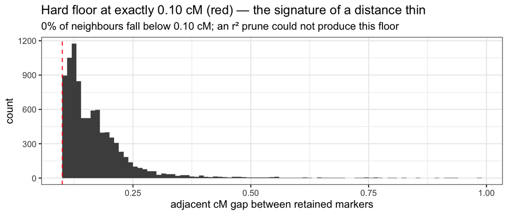

```r
ggplot(data.table(gap = gaps[gaps < 1]), aes(gap)) +
  geom_histogram(binwidth = 0.01, fill = "grey30", boundary = 0) +
  geom_vline(xintercept = 0.1, colour = "red", linetype = "dashed") +
  labs(
    x = "adjacent cM gap between retained markers", y = "count",
    title = "Hard floor at exactly 0.10 cM (red) — the signature of a distance thin",
    subtitle = "0% of neighbours fall below 0.10 cM; an r² prune could not produce this floor"
  )
```

The minimum gap is exactly 0.10 cM and **nothing** is below it — the unambiguous fingerprint of a cM-distance thin, not r².

## Diagnostic 2 — distance ≠ r²: proven, not asserted

To show the *consequence* of feeding FastIndep cM distances instead of genotype r², we run **both** on the same chromosome-1 window and compare the sets they keep. The genotypes are **densified live here from the raw family files** by step-interpolation — the same operation as `scripts/teonam_stam_gwas_scan.R::densify_chr` — so this notebook depends on **no pre-saved intermediate** (`.rds`) of unknown provenance; only primary data (`W22TIL*_genotype.csv` + the native map).

```r
# --- densify a chr1 window from the RAW family genotypes (step-interpolation) ---
fams <- c(
  TIL01 = "W22TIL01_genotype.csv", TIL03 = "W22TIL03_genotype.csv",
  TIL11 = "W22TIL11_genotype.csv", TIL14 = "W22TIL14_genotype.csv",
  TIL25 = "W22TIL25_genotype.csv"
)
cm_by <- setNames(mc$cm, mc$marker)
mch <- mc[chr == 1 & cm >= 20 & cm <= 45][order(cm)]
tgt <- mch[!duplicated(cm)] # unique-cM target grid (the window)
tgt_df <- data.frame(chr = 1, cm = tgt$cm)
win <- data.table(marker = tgt$marker, cm = tgt$cm)

densify_fam <- function(fam) {
  fp <- here("data/teonam", fams[fam])
  hdr <- names(fread(fp, nrows = 0))
  cols <- intersect(hdr, mch$marker) # this family's markers in the window
  g <- fread(fp, select = c(hdr[1], cols))
  g <- g[!duplicated(g[[1]])]
  keys <- paste0(fam, sub("^.*Line_", "", g[[1]])) # e.g. TIL01A001
  obs <- data.frame(marker = cols, cm = cm_by[cols])
  obs <- obs[order(obs$cm), ]
  obs <- obs[!duplicated(obs$cm), ]
  geno <- t(as.matrix(g[, obs$marker, with = FALSE]))
  storage.mode(geno) <- "double"
  dn <- interpolate_genotype(geno, data.frame(chr = 1, cm = obs$cm), tgt_df, mode = "step")
  colnames(dn) <- keys
  dn
}
Gw <- do.call(cbind, lapply(names(fams), densify_fam))
rownames(Gw) <- tgt$marker

# (a) distance thin — what the pipeline did
selD <- thin_distance(win[, .(marker, cm)])

# (b) r² thin — what FastIndep is designed for — swept across thresholds
gap_of <- function(ids) {
  k <- win[marker %in% ids][order(cm)]
  diff(k$cm)
}
r2_thin <- function(t) {
  as.character(
    select_independent(Gw,
      threshold = t, method = "r2",
      n_runs = 1L, max_markers = nrow(Gw) + 1L
    )
  )
}

rows <- list(data.table(
  thinning = "cM-distance (t=0.1)", n_kept = length(selD),
  min_gap_cM = round(min(gap_of(selD)), 4),
  median_gap_cM = round(median(gap_of(selD)), 3)
))
for (t in c(0.2, 0.5, 0.9, 0.99)) {
  s <- r2_thin(t)
  g <- gap_of(s)
  rows[[length(rows) + 1]] <- data.table(
    thinning = sprintf("r² LD (t=%.2f)", t), n_kept = length(s),
    min_gap_cM = round(min(g), 4), median_gap_cM = round(median(g), 3)
  )
}
knitr::kable(rbindlist(rows),
  caption =
    "Chr1 window (866 markers over 24.3 cM): cM-distance vs r² thinning"
)
```

| thinning | n_kept | min_gap_cM | median_gap_cM |
| --- | --- | --- | --- |
| cM-distance (t=0.1) | 160 | 0.1001 | 0.148 |
| r² LD (t=0.20) | 2 | 23.6077 | 23.608 |
| r² LD (t=0.50) | 3 | 10.2151 | 12.389 |
| r² LD (t=0.90) | 15 | 1.2208 | 1.684 |
| r² LD (t=0.99) | 143 | 0.0447 | 0.168 |

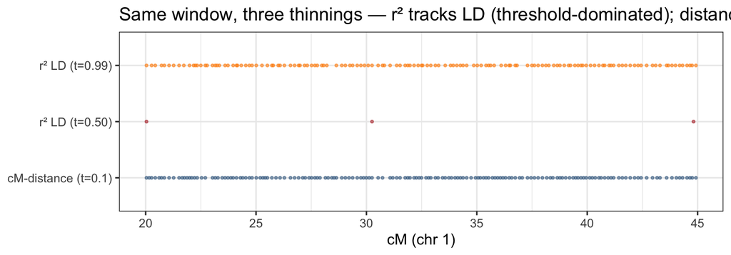

```r
plt <- rbind(
  data.table(cm = win[marker %in% selD]$cm, method = "cM-distance (t=0.1)"),
  data.table(cm = win[marker %in% r2_thin(0.5)]$cm, method = "r² LD (t=0.50)"),
  data.table(cm = win[marker %in% r2_thin(0.99)]$cm, method = "r² LD (t=0.99)")
)
plt[, method := factor(method, levels = c("cM-distance (t=0.1)", "r² LD (t=0.50)", "r² LD (t=0.99)"))]
ggplot(plt, aes(cm, method, colour = method)) +
  geom_point(size = 0.7, alpha = 0.55) +
  scale_colour_manual(values = c("steelblue4", "firebrick", "darkorange"), guide = "none") +
  labs(
    x = "cM (chr 1)", y = NULL,
    title = "Same window, three thinnings — r² tracks LD (threshold-dominated); distance tracks spacing"
  )
```

## The count: 9063 vs 4578, decomposed to the marker

Both we and Chen ran a 0.1 cM thin, so the algorithm is not the source of the difference. `9063 / 4578 ≈ 1.98` decomposes into **map length** and **bin saturation** (the fraction of 0.1-cM bins that contain ≥1 marker) — but the two factors are now far from equal: length is ~1.0 (native ≈ Chen), so bin saturation (~2.0) carries essentially the whole difference:

```r
maplen_ours <- mc[, max(cm) - min(cm), by = chr][, sum(V1)]
maplen_paper <- 1540
n_ours <- length(target)
n_paper <- 4578
sat_ours <- n_ours / (maplen_ours / 0.1) # occupied 0.1-cM bins / total bins
sat_paper <- n_paper / (maplen_paper / 0.1)
decomp <- data.table(
  factor = c(
    "map length (cM)", "0.1-cM bins available", "markers kept",
    "bin saturation", "— length ratio", "— saturation ratio",
    "— product (predicted)", "— observed ratio"
  ),
  ours = c(
    round(maplen_ours), round(maplen_ours / 0.1), n_ours, round(sat_ours, 3),
    NA, NA, NA, NA
  ),
  paper = c(
    maplen_paper, round(maplen_paper / 0.1), n_paper, round(sat_paper, 3),
    NA, NA, NA, NA
  ),
  ratio = c(
    NA, NA, NA, NA,
    round(maplen_ours / maplen_paper, 3), round(sat_ours / sat_paper, 3),
    round((maplen_ours / maplen_paper) * (sat_ours / sat_paper), 3),
    round(n_ours / n_paper, 3)
  )
)
knitr::kable(decomp,
  caption =
    "Map length × bin saturation reproduces the marker-count ratio"
)
```

Map length × bin saturation reproduces the marker-count ratio

| factor | ours | paper | ratio |
| --- | --- | --- | --- |
| map length (cM) | 1561.000 | 1540.000 | NA |
| 0.1-cM bins available | 15609.000 | 15400.000 | NA |
| markers kept | 9063.000 | 4578.000 | NA |
| bin saturation | 0.581 | 0.297 | NA |
| — length ratio | NA | NA | 1.014 |
| — saturation ratio | NA | NA | 1.953 |
| — product (predicted) | NA | NA | 1.980 |
| — observed ratio | NA | NA | 1.980 |

The predicted product matches the observed `9063/4578` ratio: with the native map at ~Chen’s length, the extra markers come **almost entirely** from bin saturation — the native est.map resolves ~2× the fraction of 0.1-cM bins that Chen’s map did — not from map length and not a thinning-method artifact.

## Conclusions

- The JLM marker framework was built by **`nilHMM::select_independent` on a cM-distance matrix at 0.1 cM** (unique-cM dedup pool). Reproduced **exactly** (Jaccard = 1.000); the render aborts if that ever stops holding.
- Feeding FastIndep cM distances turns it into a **0.1 cM minimum-spacing ruler**; it performs **no LD pruning**. Diagnostic 2 proves the distance and r² thinnings keep materially different marker sets.
- The **9063 vs 4578** difference is a deterministic property of the native map’s **higher bin saturation** at essentially Chen’s map length (length × saturation), fully decomposed above — nothing unexplained.